# Evolution des géométries politiques

Le cas du Maine-et-Loire (49)

Author

Claude Grasland

## Objectif

On se propose d’examiner les modifications de la géométrie politique du département entre 2007 et 2022 en se servant des données CARTELEC pour la description de la situation avant 2010 et des données INSEE pour la situation actuelle en 2022.

## (A) Bureaux de vote

### Evolution du nombre

Quel est le nombre de bureaux de vote à chacune des dates ? quelles évolutions observe-t-on dans les communes les plus découpées ?

| date | source | nb |
| --- | --- | --- |
| 2007 | CARTELEC | 459 |
| 2022 | INSEE | 692 |

| code | nom | nb1 | nb2 | var |
| --- | --- | --- | --- | --- |
| 49007 | Angers | 79 | 83 | 4 |
| 49099 | Cholet | 1 | 35 | 34 |
| 49331 | Segré-en-Anjou-Bleu | 1 | 21 | 20 |
| 49023 | Beaupréau-en-Mauges | 1 | 20 | 19 |
| 49092 | Chemillé-en-Anjou | 1 | 20 | 19 |
| 49301 | Sèvremoine | 1 | 19 | 18 |
| 49328 | Saumur | 19 | 19 | 0 |
| 49018 | Baugé-en-Anjou | 1 | 17 | 16 |

## (B) Cantons

### Situation avant 2015

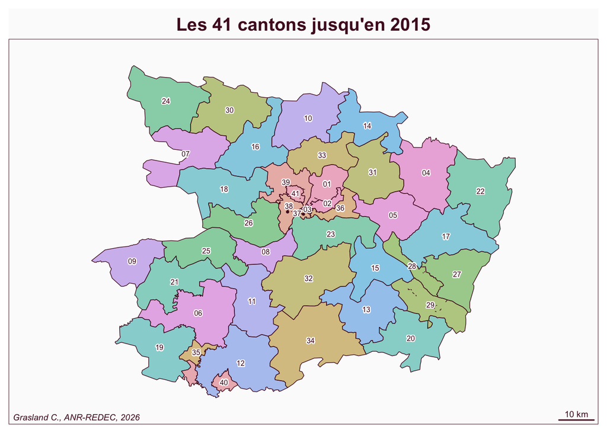

### Situation après 2015

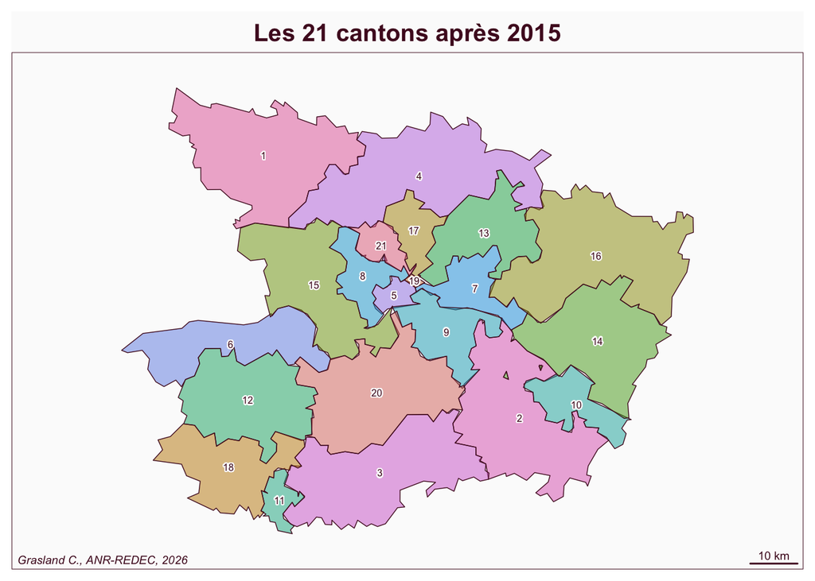

## Fusion ou redécoupage ?

Comment s’est opéré la réduction de moitié des cantons ?

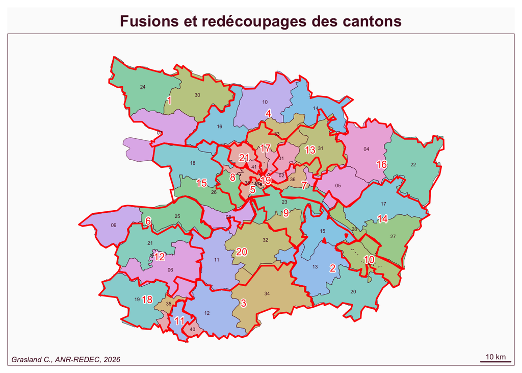

- **Commentaire** : Compte-tenu des variations de la croissance de population, le nombre de cantons fusionnés est très variable. Dans les zones rurales périphériques, on a souvent fusionné 3 voire 4 cantons. Au contraire, dans les zones denses et en croissance, le nombre de cantons a pu être plus faible. Mais dans tous les cas on a beaucoup chamboulé les limites antérieures.

## (C) Circonscriptions

Le redécoupage des circonscriptions s’est opéra en principe à partir de la brique de base des anciens cantons.

### Situation avant 2010

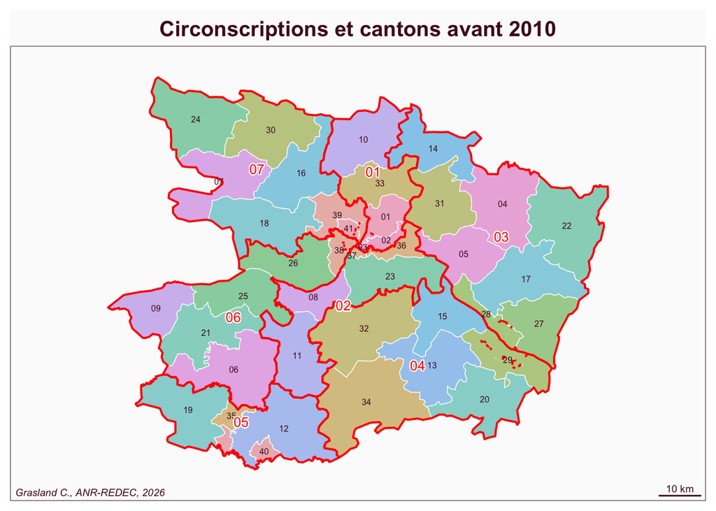

### Situation en 2010-2015

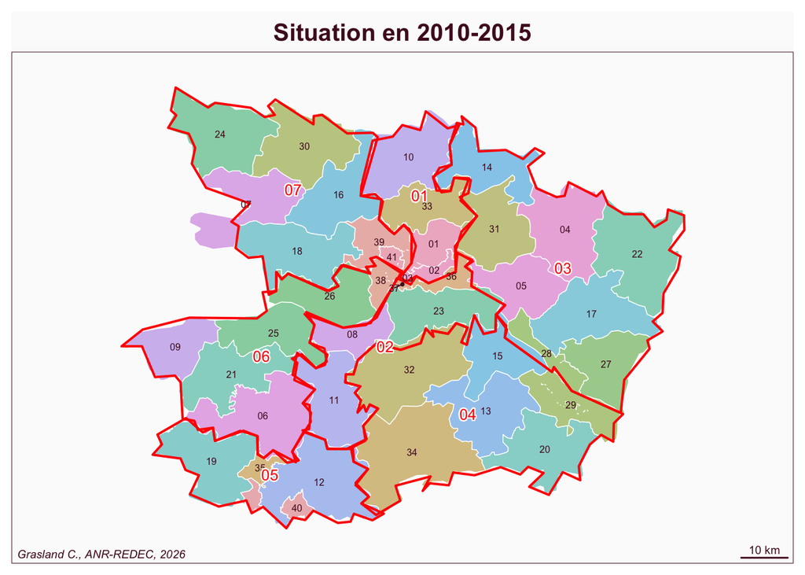

### Situation depuis 2015

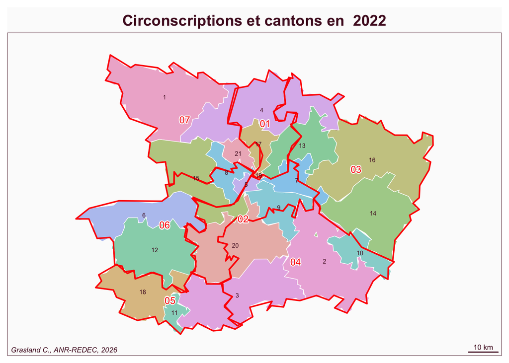

- **Commentaire** : sous le double effet des deux réformes, il n’y a presque plus de correspondances entre les limites de canton et de circonscriptions